# Population of black-tail jackrabbits in Sevilleta National Wildlife Refuge

# Introduction

In this report, I investigated the time series data of the population of black-tail jackrabbits (Lepus californicus) in the grasslands and creosote shrublands of McKenzie Flats, Sevilleta National Wildlife Refuge. Rabbits are important herbivores in such habitats. One one hand, rabbits are prey for many carnivores in the environment, and on the other hand, it can influence net primary productivity and plant species composition. The population and density of rabbits can also be used to estimate the herbivore pressure on the plant communities. The study of the rabbit population in Sevilleta National Wildlife Refuge was initiated in January 1992, and continues quarterly each year. Rabbits were sampled via night-time spotlight transect sampling at a specific location once during winter, spring, summer, and fall. In order to learn more about the flutuation of the rabbit population, I aim to find a decent model to fit this time series data. Specifically, I applied both SARMA model and a POMP model on this dataset.

# Data Exploration

The data was first published on the Long Term Ecological Research (LTER) Network Data Portal, including the information for each observed rabbit. We do not need these additional information, so I preprocessed the dataset (codes not shown in this report). After cleaning, the dataset includes the count numbers of black-tail jackrabbits observed in each season starting from Winter 1992:

```
##   Season Count
## 1      1    11
## 2      2    21
## 3      3    11
## 4      4    17
## 5      5    22
## 6      6    44
```

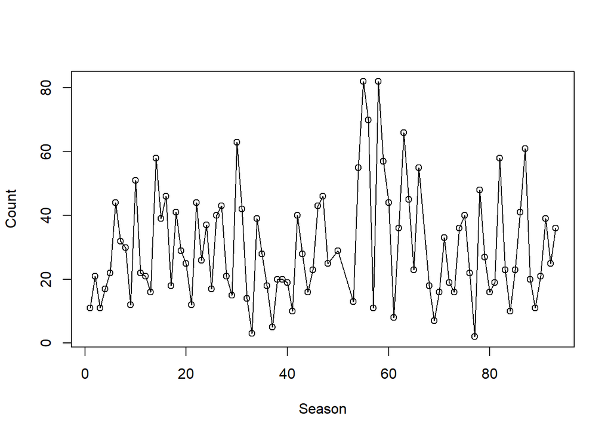

We use the acf plot and smoothed spectrum plot to check the periodic patterns of the data:

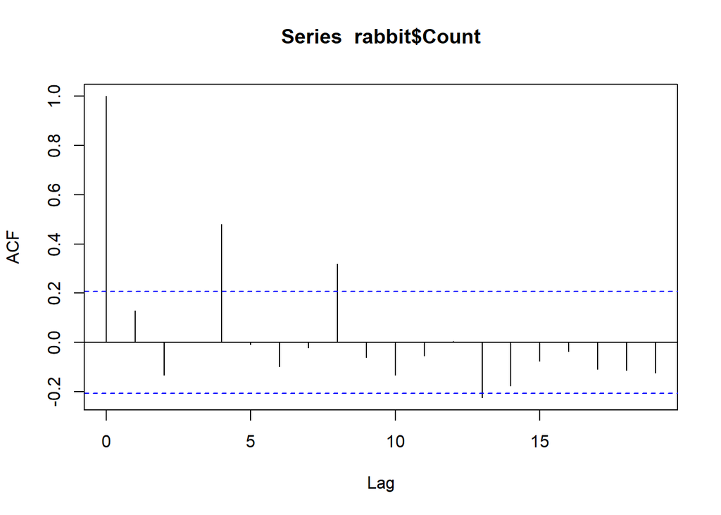

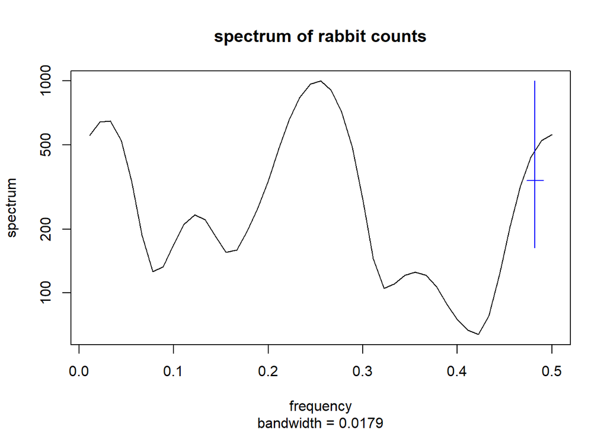

Easy to see from the previous plots, there is a significant cycle of every four seasons (every year).

# Fitting a SARMA model

We use a SARMA model to fit our rabbit data to account for the seasonality (a yearly period) we observed.

$$(1-\Phi_p B^{4})(1-\phi_p B) X_n = (1+\psi_q B)\epsilon_n$$

|  | MA0 | MA1 | MA2 | MA3 | MA4 | MA5 |
| --- | --- | --- | --- | --- | --- | --- |
| **AR0** | 745.19 | 742.27 | 744.12 | 745.97 | 747.56 | 748.91 |
| **AR1** | 743.03 | 744.16 | 742.59 | 744.56 | 749.31 | 749.69 |
| **AR2** | 743.97 | 745.70 | 747.70 | 746.31 | 748.01 | 747.55 |
| **AR3** | 745.91 | 747.70 | 749.63 | 746.96 | 749.05 | 750.28 |
| **AR4** | 746.47 | 748.43 | 750.34 | 744.78 | 746.54 | 751.18 |

The AIC table suggests that SARMA(0,1) is the optimal model for the data.

```
##
## Call:
## arima(x = rabbit$Count, order = c(0, 0, 1), seasonal = list(order = c(1, 0,
##     0), period = 4), method = "ML")
##
## Coefficients:
##          ma1    sar1  intercept
##       0.2521  0.5084    29.5571
## s.e.  0.1075  0.0897     3.8362
##
## sigma^2 estimated as 221:  log likelihood = -367.14,  aic = 742.27
```

We can plot the residuals of this SARMA(0,1) model, and check its acf and normality:

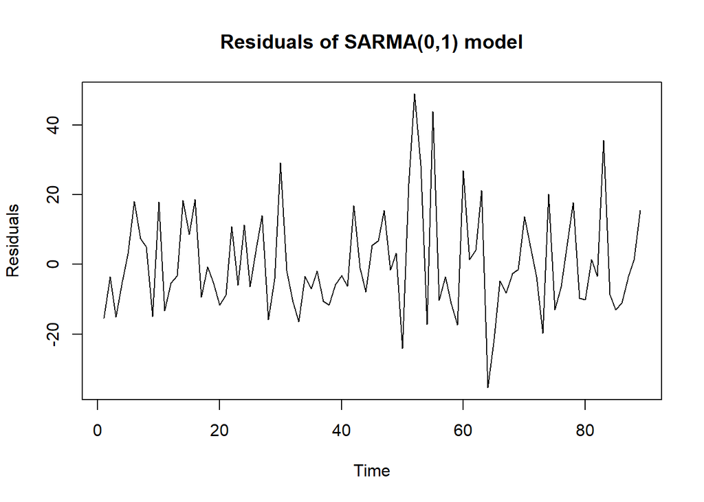

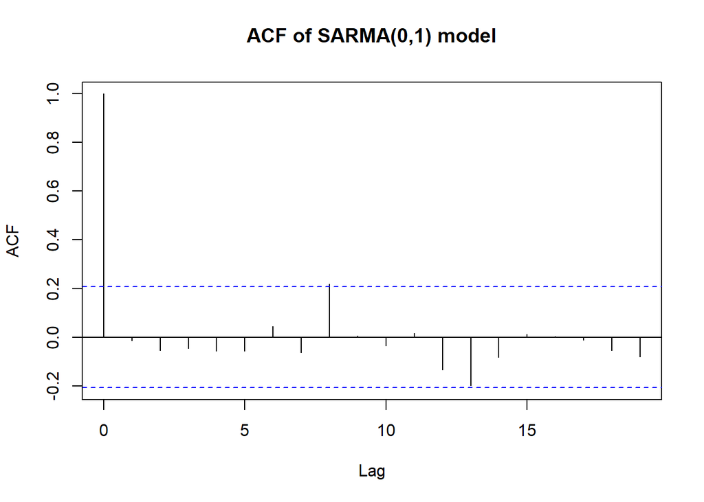

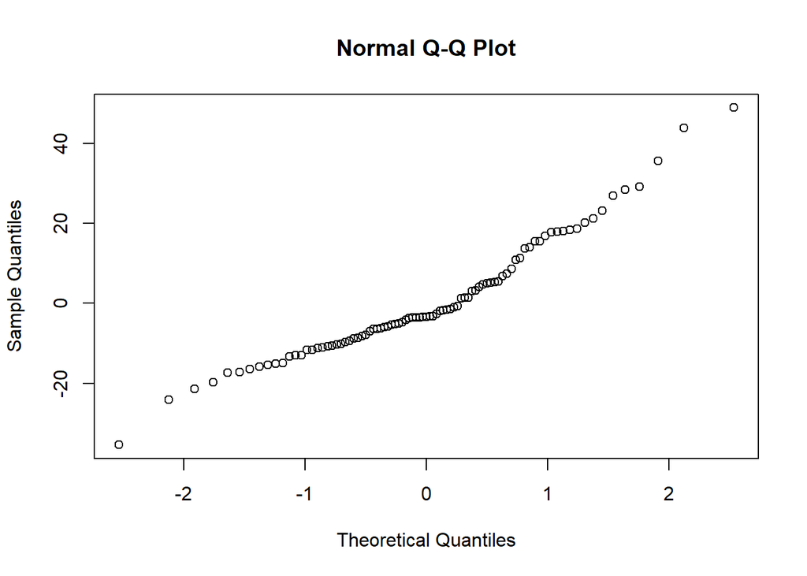

The acf plot indicates that the residuals are mostly independent. QQ-plot shows that the residuals do not follow a normal distribution.

To sum all above, we find that the best SARMA model for our data is SARMA(0,1). The MA1 and coefficient and the SAR1 coefficient are determined to be 0.2521 and 0.5084 respectively, with a loglikelihood of -367.14.

# Fitting a POMP model

Next, we fit our data to a POMP model. We apply the widely used Beverton-Holt model:
$$P_{n+1} = \frac{a\,P_n}{1+b\,P_n}\,\varepsilon_n,$$

where $a$ can be interpreted as the proliferation rate per generation and $(a-1)/b$ is the carrying capacity of the environment. The noise process, $\varepsilon$, follows a lognormal distribution:

$$\varepsilon_t \sim \mathrm{Lognormal}(-\tfrac{1}{2}\sigma^2,\sigma^2).$$

and the measurement model is:

$$Y_{n}|P_n\;\sim\;\mathrm{Poisson}(\phi\,P_{n})$$
.

where in this report, $\phi$ is set to be one.

First, we construct a pomp object:

```r
rabbits = pomp(rabbit,times="Season",t0=0)
skel = Csnippet("DN = (a*N)/(1+(b*N));")
stochStep = Csnippet("e = rlnorm(-0.5*sigma*sigma,sigma);N = ((a*N)/(1+(b*N)))*e;")
rmeas = Csnippet("Count = rpois(phi*N);")
dmeas = Csnippet("lik = dpois(Count,phi*N,give_log);")

pomp(rabbits,rmeasure=rmeas,dmeasure=dmeas,
     skeleton=map(skel),
     rprocess=discrete.time.sim(step.fun=stochStep,delta.t=1),
     paramnames=c("a","b","sigma","phi"),
     statenames=c("N","e"))->rabbits
```

We can look at the simulation plot of the model:

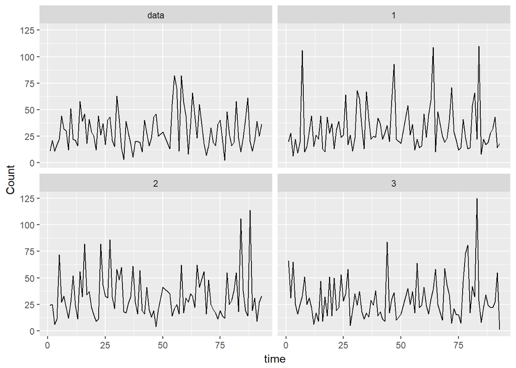

```r
coef(rabbits) = c(N.0=100,e.0=0,a=60,b=2,sigma=0.55,phi=1)
sims = simulate(rabbits,nsim=3,as.data.frame=TRUE,include.data=TRUE)

ggplot(data = sims, mapping = aes(x = time, y = Count)) + geom_line() + facet_wrap(~sim)
```

The simulations look moderately similar to the real data. We then investigate how the likelihood changes with the parameters by constructing a likelihood slice. The specific codes and plots are shown below:

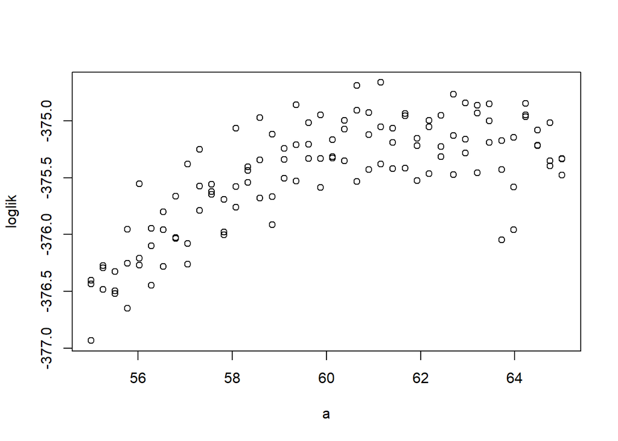

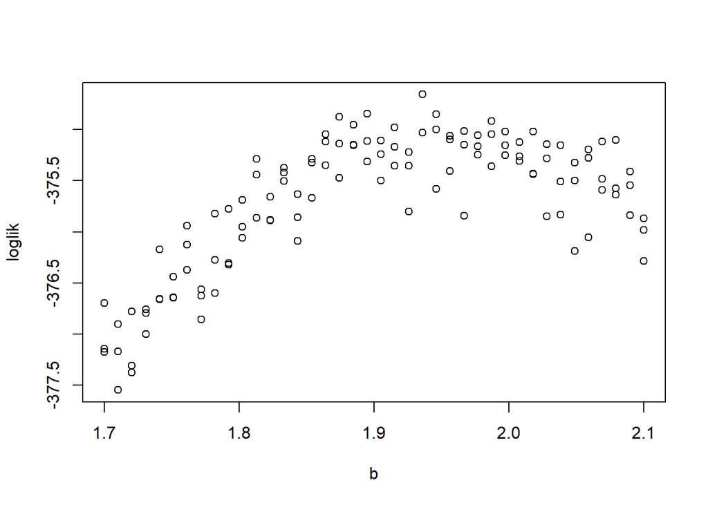

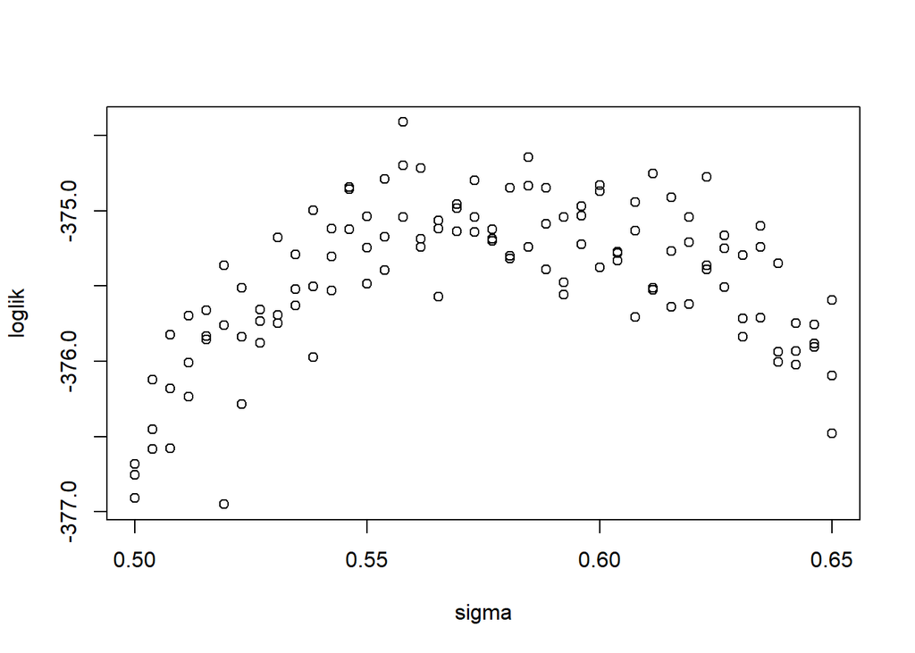

```r
sliceDesign(
  c(N.0=100,e.0=0,a=60,b=2,sigma=0.55,phi=1),
  a=rep(seq(from=55,to=65,length=40),each=3),
  b=rep(seq(from=1.7,to=2.1,length=40),each=3),
  sigma=rep(seq(from=0.5,to=0.65,length=40),each=3)) -> p

rabbit_mle=unlist(p[which.max(p$loglik),])

registerDoMC(cores=4)

set.seed(998468235L,kind="L'Ecuyer")
mcopts <- list(preschedule=FALSE,set.seed=TRUE)

foreach(theta=iter(p,"row"),.combine=rbind,
         .inorder=FALSE,.options.multicore=mcopts) %dopar%
         {
           pfilter(rabbits,params=unlist(theta),Np=5000) -> pf
           theta$loglik <- logLik(pf)
           theta
         } -> p

foreach (v=c("a","b","sigma")) %do%
{
  x <- subset(p,slice==v)
  plot(x[[v]],x$loglik,xlab=v,ylab="loglik")
}
```

Next, we can evaluate the log likelihood of the data given the model and the parameters. We use the particle filter to get an estimate of the Monte Carlo variability:

```r
simulate(rabbits,params=c(N.0=100,e.0=0,a=60,b=2,sigma=0.55,phi=1),nsim=10000,states=TRUE) -> x

ell = dmeasure(rabbits,y=obs(rabbits),x=x,times=time(rabbits),log=TRUE,
               params=c(N.0=100,e.0=0,a=60,b=2,sigma=0.55,phi=1))
dim(ell)
```

```
## [1] 10000    89
```

```r
ell = apply(ell,1,sum); summary(exp(ell)); logmeanexp(ell,se=TRUE)
```

```
##    Min. 1st Qu.  Median    Mean 3rd Qu.    Max.
##   0e+00   0e+00   0e+00   0e+00   0e+00  4e-308
```

```
##                    se
## -716.90269   23.05423
```

```r
pf = pfilter(rabbits,Np=5000,params=c(N.0=100,e.0=0,a=60,b=2,sigma=0.55,phi=1))
logLik(pf)
```

```
## [1] -375.0602
```

```r
pf <- replicate(10,pfilter(rabbits,Np=5000,params=c(N.0=100,e.0=0,a=60,b=2,sigma=0.55,phi=1)))
ll <- sapply(pf,logLik); ll
```

```
##  [1] -375.1672 -374.9260 -375.4498 -375.5034 -374.9185 -374.9190 -375.2584
##  [8] -375.3053 -375.5308 -375.5392
```

```r
logmeanexp(ll,se=TRUE)
```

```
##                          se
## -375.22129870    0.08390506
```

From the results, we obtain an unbiased likelihood estimate of -375.2 with a standard error of 0.08.

Next, we search for the MLE of the parameters using particle filter. We first do a local search around the previously identified MLE based on the information from the likelihood surface slice.

```r
# Set run levels
run_level <- 3
switch(run_level,
       {rabbits_Np=100; rabbits_Nmif=10; rabbits_Neval=4; rabbits_Nglobal=10; rabbits_Nlocal=10},
       {rabbits_Np=1000; rabbits_Nmif=100; rabbits_Neval=10; rabbits_Nglobal=20; rabbits_Nlocal=20},
       {rabbits_Np=10000; rabbits_Nmif=300; rabbits_Neval=20; rabbits_Nglobal=100; rabbits_Nlocal=20}
)



# Local search for MLE
stew(file=sprintf("rabbits_local_search-%d.rda",run_level),{

  t_local <- system.time({
    mifs_local <- foreach(i=1:rabbits_Nlocal,.packages='pomp', .combine=c, .options.multicore=mcopts) %dopar%  {
      mif2(
        rabbits,
        start=c(N.0=100,e.0=0,a=60,b=2,sigma=0.55,phi=1),
        Np=rabbits_Np,
        Nmif=rabbits_Nmif,
        cooling.type="geometric",
        cooling.fraction.50=0.5,
        transform=TRUE,
        rw.sd=rw.sd(
          a=0.01,
          b=0.005,
          sigma=0.001
        )
      )

    }
  })

},seed=900242057,kind="L'Ecuyer")


stew(file=sprintf("rabbits_lik_local-%d.rda",run_level),{
  t_local_eval <- system.time({
    liks_local <- foreach(i=1:rabbits_Nlocal,.packages='pomp',.combine=rbind) %dopar% {
      evals <- replicate(rabbits_Neval, logLik(pfilter(rabbits,params=coef(mifs_local[[i]]),Np=rabbits_Np)))
      logmeanexp(evals, se=TRUE)
    }
  })
},seed=900242057,kind="L'Ecuyer")

rabbits_results_local <- data.frame(logLik=liks_local[,1],logLik_se=liks_local[,2],t(sapply(mifs_local,coef)))
summary(rabbits_results_local$logLik,digits=5)
```

```
##    Min. 1st Qu.  Median    Mean 3rd Qu.    Max.
##  -374.9  -374.8  -374.8  -374.8  -374.8  -374.8
```

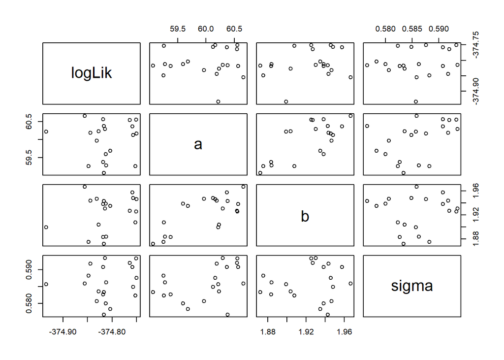

```r
pairs(~logLik+a+b+sigma,data=subset(rabbits_results_local,logLik>max(logLik)-50))
```

The evaluation of the best result of this search gives a likelihood of -374.8. The plots can give us a sense of the geometry of the likelihood surface in the neighbor of this point estimate.

Finally, we maximize the likelihood on a global scale:

```r
# Global likelihood maximization
rabbits_box <- rbind(
  a=c(20,100),
  b=c(0.5,4),
  sigma = c(0.4,0.8)
)

rabbits_fixed_params<-c(N.0=100,e.0=0,phi=1)

stew(file=sprintf("box_eval-%d.rda",run_level),{

  t_global <- system.time({
    mifs_global <- foreach(i=1:rabbits_Nglobal,.packages='pomp', .combine=c, .options.multicore=mcopts) %dopar%  mif2(
      mifs_local[[1]],
      start=c(apply(rabbits_box,1,function(x)runif(1,x[1],x[2])),rabbits_fixed_params)
    )
  })
},seed=1270401374,kind="L'Ecuyer")


stew(file=sprintf("lik_global_eval-%d.rda",run_level),{
  t_global_eval <- system.time({
    liks_global <- foreach(i=1:rabbits_Nglobal,.packages='pomp',.combine=rbind, .options.multicore=mcopts) %dopar% {
      evals <- replicate(rabbits_Neval, logLik(pfilter(rabbits,params=coef(mifs_global[[i]]),Np=rabbits_Np)))
      logmeanexp(evals, se=TRUE)
    }
  })
},seed=442141592,kind="L'Ecuyer")

rabbits_results_global <- data.frame(logLik=liks_global[,1],logLik_se=liks_global[,2],t(sapply(mifs_global,coef)))
summary(rabbits_results_global$logLik,digits=5)
```

```
##    Min. 1st Qu.  Median    Mean 3rd Qu.    Max.
##  -375.2  -374.9  -374.8  -374.8  -374.8  -374.7
```

The evaluation of the best result of this search gives a likelihood of -374.7. The following plots can give us a sense of the global geometry of the likelihood surface.

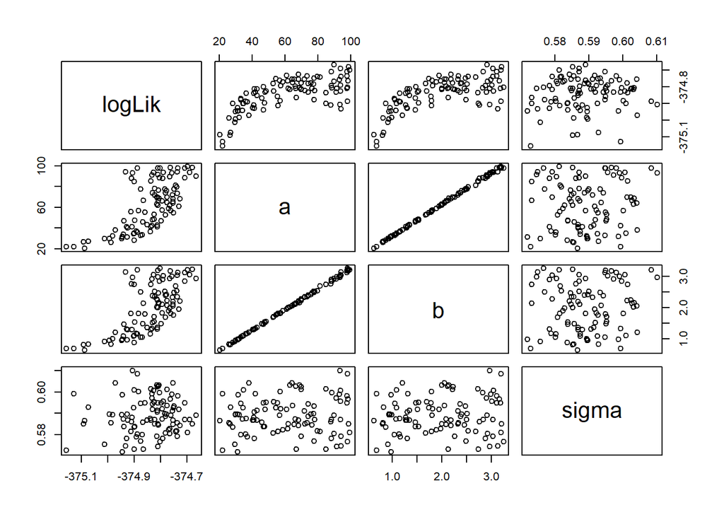

```r
if (run_level>2)
  write.table(rbind(rabbits_results_local,rabbits_results_global),
              file="mif_rabbits_params.csv",append=TRUE,col.names=FALSE,row.names=FALSE)

pairs(~logLik+a+b+sigma,data=subset(rabbits_results_global,logLik>max(logLik)-250))
```